# Zambia FISP - Index Insurance Basis Risk Fund Design Proposal

[figure not shown]

## 0. Overview

### 0.1 Executive Summary

#### Key Messages

- There are tradeoffs in **cost, timeliness and reliability** between weather and area yield index insurance.
- The **currently offered** weather index insurance products in Zambia would cover about **30%** of farmers’ reported historical risks.
- Introducing a **yield audit** component to the insurance would allow it cover about **50-60%** of farmers’ historical risks.
- Adding yield audits would increase the **total value** of insurance claims by about **25%**.
- Satellite-based weather indices are about **twice as effective** at measuring drought events as compared to excess rainfall events.

#### Program Implications

- Many of the activities necessary for a yield audit system could be **integrated into existing MoA operations** like the Crop Forecast Survey.
- In 2021/22, **targeting yield audits** based on a combination of weather indices and extension officers’ feedback would have:
  - Required **just ~1/5th as many yield assessments**,
  - Identified the **majority** of districts experiencing low yields.
- **Simple indices based on farmers’ input** would perform as well or better at capturing farmers’ risks as other WII products.

### 0.2 Purpose of Document

Since the 2017/18 season, the Government of the Republic of Zambia (GRZ) has run an agricultural index insurance program for smallholder farmers under the Ministry of Agriculture (MoA)’s Farm Input and Support Program (FISP), with support for the UN World Food Programme (WFP). The program has covered nearly 4 million cumulative farmers over its lifespan.

The program has offered two modalities of insurance: Weather index insurance (WII), based on satellite measurements of rainfall, and area yield insurance, based on a random sample of crop cuts. Both types of insurance have advantages and disadvantages. WII is low-cost, readily available and transparent, but it may miss key aspects of farmers’ experience due the imprecision of satellites or the assumptions of the payout model. Also, WII cannot capture non-weather risks to the harvest such as pests.

Conversely, area yield (AY) is based on direct samples of crop performance, which lack these drawbacks - but it is costly and time-consuming to implement, and subject to its own sources of imprecision. Moreover, it is often difficult to set a transparent, reliable standard for when an area yield index should pay out due to the lack of a historical yield record.

This document outlines a revised approach to index insurance in which the two modalities complement one another. The proposed new design is based primarily on WII, but backstopped with a system of area yield “audits” targeted to places where WII fails to capture farmers’ risk.

The first part of this document describes how the program could be financed. The second part of the document describes the procedure for carrying out these yield audits.

### 0.3 Approach

To forecast the cost of the yield audit system, we must have an estimate of how likely it is to trigger - that is, how likely it is that the WII component of the product would miss a risk event. To estimate this, we use MoA / WFP’s survey data on farmers’ worst drought and excess rainfall years, which covers nearly 1,000 villages sampled from the entire country ([**details here**](https://fist.iri.columbia.edu/publications/docs/BetterIndexesZambia/)). Our estimation proceeds in four steps:

- Normalize all datasets (farmers’ bad years, yield, weather insurance) to reflect only the worst 25% of historical events.
- Calculate how many of farmers’ historical bad years would be captured by weather insurance alone.
- Calculate how many additional bad years would be captured if yield audits were conducted when weather insurance failed to pay out in a bad year.
- Quantify the value of those yield audits in terms of what the payouts “should have been” if the product had no basis risk (i.e., farmers’ worst year received the largest payout, the second worst year received the second largest payout, etc.)
- Quantify the value of the remaining basis risk after introducing yield audits, using the same method.

For our information on historical WII payouts, we primarily use the product designed by the GrZ / WFP / insurer Technical Working Group (TWG), [**described here**](https://fist.iri.columbia.edu/publications/docs/zambiaFISPindexdesign2021/). We also consider products from ACRE and AgRiskShield with similar designs, as well as a “default” index in which contract periods are based on farmers’ reported seasonal calendar only.

For our information on historical yields, we use the MoA Crop Forecast Survey (CFS) province-level detrended maize yields. (Note that IRI is currently working on compiling the district-level CFS data, and this report will be updated when it is available.)

It is important to note that no source of information about historical risk is perfect - farmer recall, weather measurements, crop forecast surveys and area yield samples all have their own sources of noise and bias. Thus, the estimates presented in this report should be considered a conservative upper bound on the level of basis risk present in WII.

### 0.4 Districts Considered for Case Study

We divide the districts of Zambia into three zones based on which climate hazard(s) are most common, per the TWG’s input. We use these zones in the subsequent analysis.

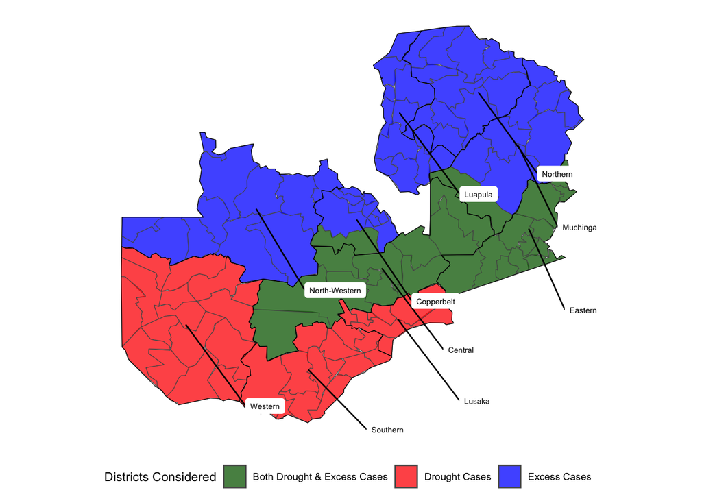

## 1. Results - Financial

This section describes the estimated cost breakdown and reliability of a blended (WII + AY) product using historical data.

#### Note: All WII products considered in this report have had their data normalized to the same claims ratio.

See Appendix 3.1 for details.

### 1.1 WII Product Performance

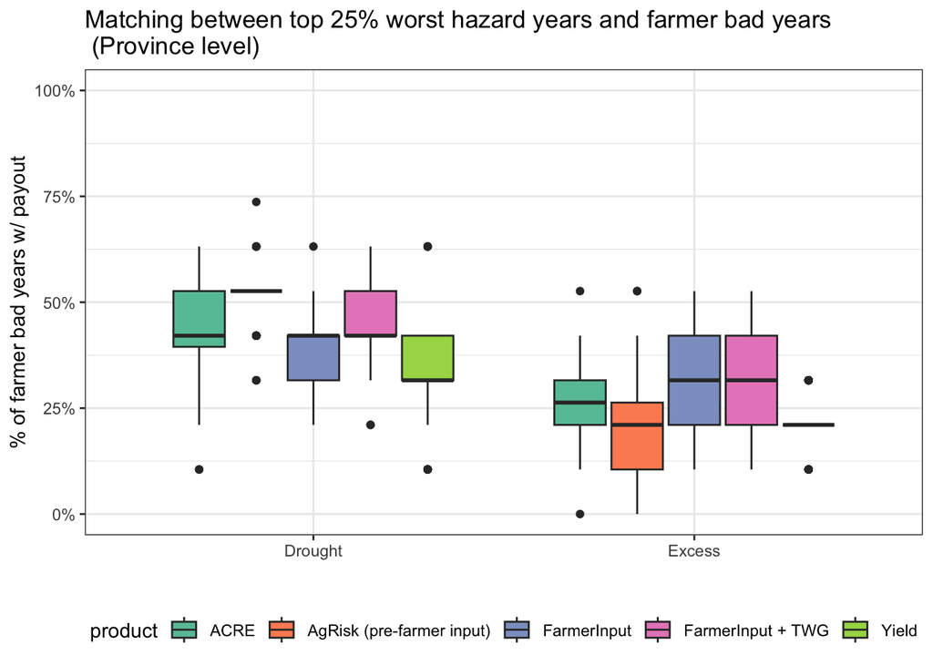

This graph shows the distribution of the percentage of farmers’ top 8 worst weather years (drought or excess) during which there would have been a significant (top 25% by value) WII payout. This number is our basis for estimating the “payout gap”; i.e., the amount of claims which would need to be paid out in addition to WII in order to fully compensate farmers for their reported losses.

For example, if a location has 75% matching, it means that the yield audit would be intended to trigger for 2 (8*0.25) of farmers’ worst years out of the last ~40. The following sections translate this quantity into a monetary estimate of the payout gap.

This data is averaged to the province level to illustrate the overall performance of each product. We would expect the province-level average data to have less error / noise than the district level data, although it may not capture local-level differences in historical risk.

Subsequent analyses in this report use the district-level data, to better reflect the scale at which the index was originally calculated.

#### **District by district, less than half of farmers’ bad years would present a significant WII payout.**

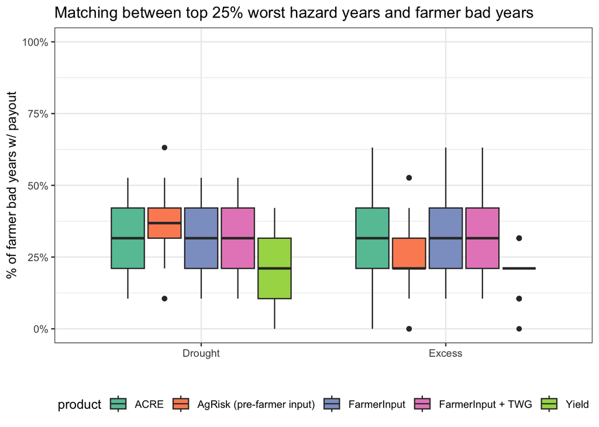

For both hazards, we see fewer than 50% of farmers’ bad years on average would have presented a significant payout. This motivates a complementary risk fund such as the one described in this report.

### 1.2 WII + Yield Audit Performance

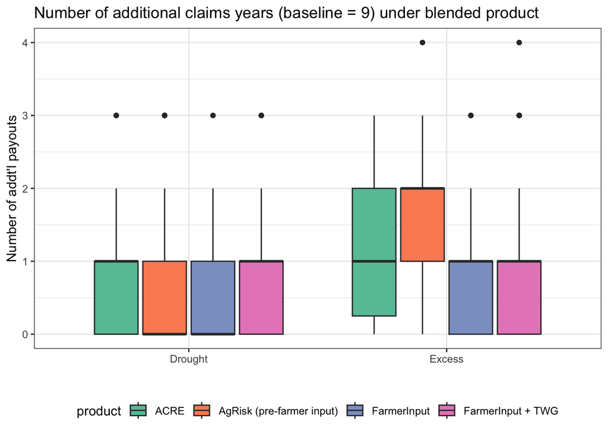

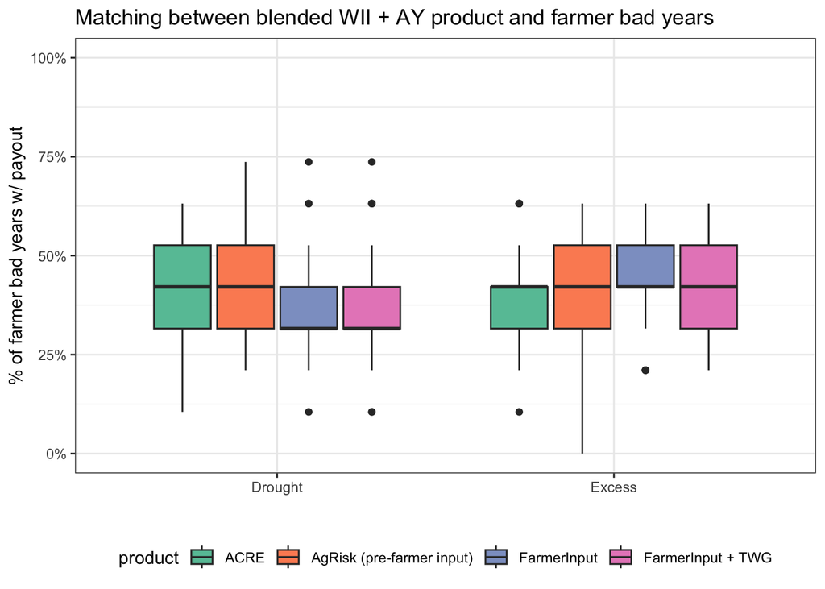

Introducing yield audits when WII fails to pay out in a bad year would bring the overall matching rate of the insurance product to around 50% of farmers’ bad years. However, this would require claims to be paid out in an average of 1-2 more years over the last 40 (where the baseline is 9 years out of the last 40).

### 1.3 Audit Fund and Basis Risk Valuation

#### **The blended WII + AY product would have about 25% more total claims than WII alone.**

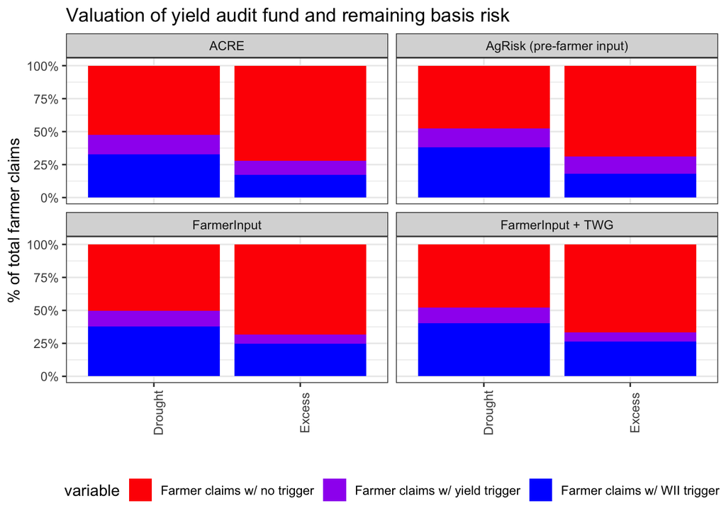

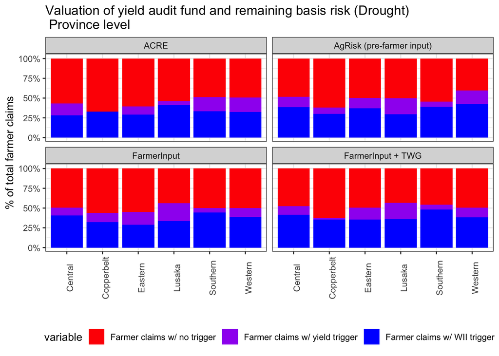

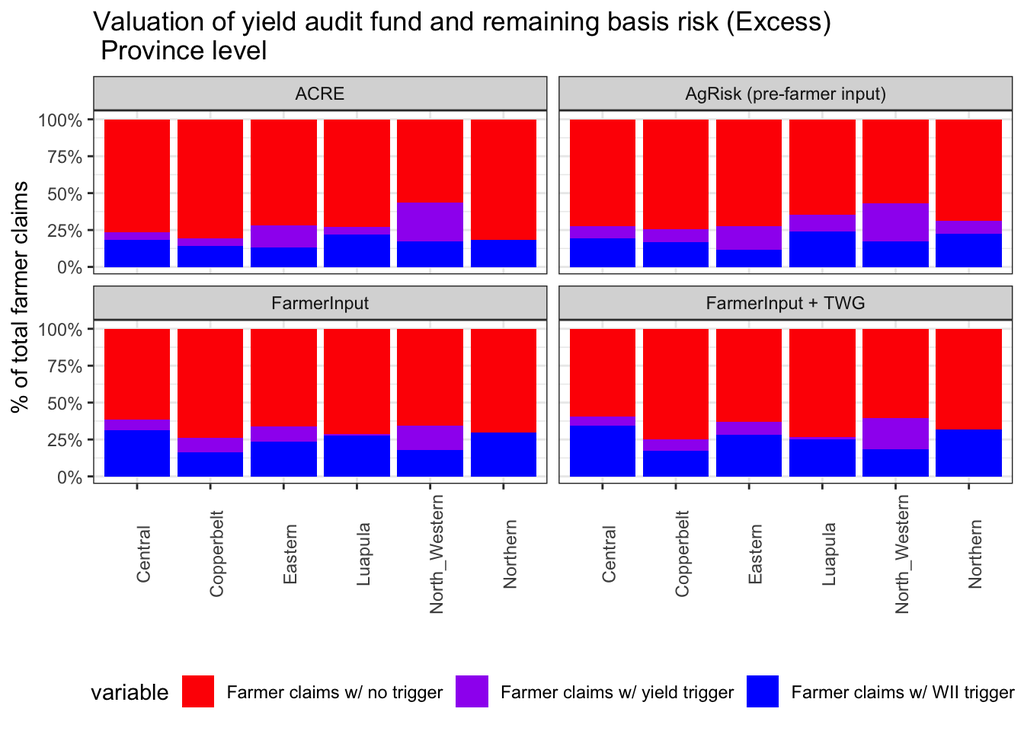

We can quantify the value of these yield audit-based payouts, as well as the remaining basis risk, by mapping the current product’s historical payout values onto farmers’ worst years. For instance, farmers’ worst year “should have” received the largest payout, and so on.

Since the various WII products have different claims ratios, we normalize these figures by the total historical claims for that product.

We can also express the additional cost of the yield audit system as a percentage increase in the amount of claims that would have to be paid out:

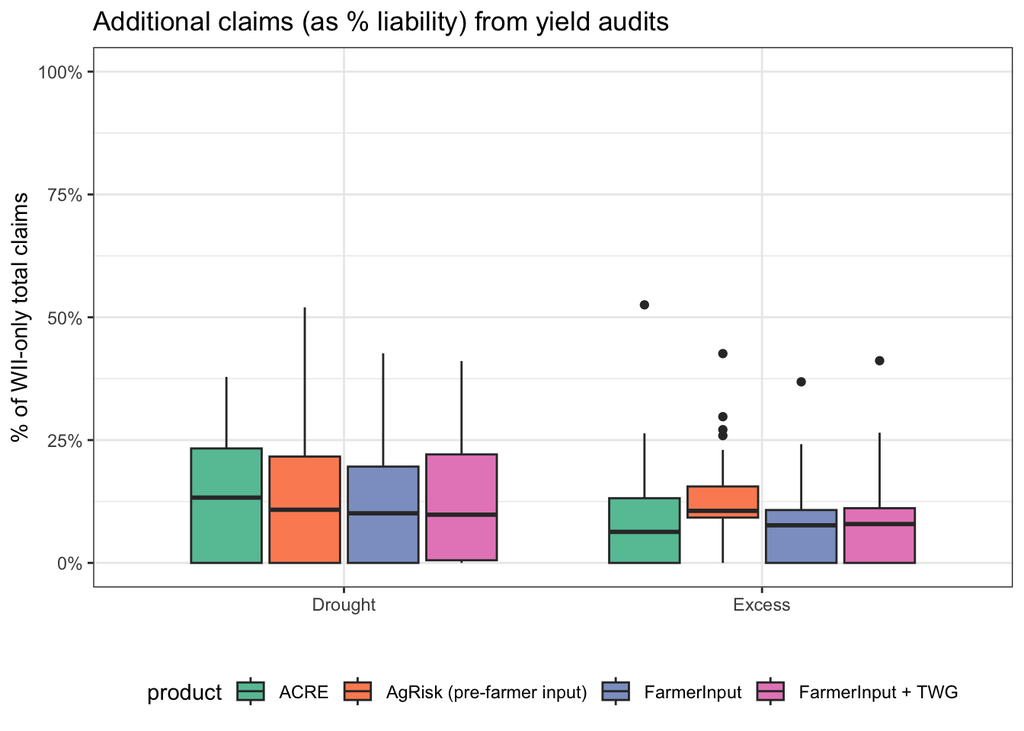

However, there are trade-offs - AY assessments take much longer to conduct and are more costly than WII. The final decision will come down to the TWG’s judgement of these relative costs and benefits.

Finally, it is important to reiterate that no insurance modality is perfect, and farmer recall has imprecision and biases. Therefore, there will always be some amount of reported risk which insurance cannot cover.

## 2. Results - Audit Procedure

A key aspect of this blended product is that there must be a clearly defined procedure for when a yield audit should be carried out. The retrospective analysis in Section 1 relies on farmers’ historical recall of their worst harvest years to approximate this; however, looking forward, we cannot know this information. Instead, we must rely on leading indicators of how the current season is unfolding.

This section focuses on one such indicator, which is MoA extension officers’ reports from the field during the 2021/22 season. We compare these reports against the TWG WII product’s estimated payouts as well as area yield data from both Pula and the MoA CFS. Finally, we discuss implications for a monitoring system moving forward.

### 2.1 Comparison of 2021/22 Data Sources

#### **The 2021/22 season was significantly below average in many places, according to multiple sources.**

We have Pula’s maize crop cut data for the 2021/22 season for about 2,700 sites across the country. These sites, shown in green below, appear to be geographically representative of where farmers were surveyed by the MoA in 2020, shown in yellow below.

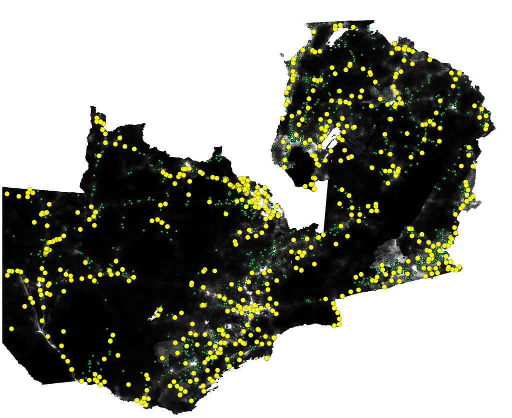

We do not have historical yield data from Pula, so it is difficult to determine whether each site should have received a payout in 2021/22 from their data alone. To provide a historical benchmark, we use the MoA CFS data to calculate a historical average and variance of maize yield in each province. The below maps show the z-score (difference in standard deviations) from that historical average for the 2021/22 season. We present that result for the Pula crop cut data as well as the 2021/22 CFS data alone.

Crucially, both datasets indicate that similar areas of the country experienced significantly below-average yield conditions in 2021/22. This, along with the results of Section 1, suggest that the MoA’s own crop yield assessments could perform just as well as a third party’s in terms of capturing farmers’ most significant risks.

#### **Both Pula and the CFS crop cut data identified similar areas as below the historical average yield.**

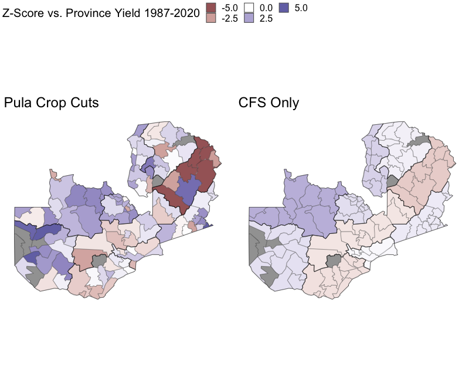

We can go further and calculate what the Pula AY index payout could have been in 2021/22, using a simple pricing formula in which a payout is triggered for the worst 20% of historical yield years and the maximum liability of 2000 ZMW is reached during the very worst historical yield year. We compare the results of such an index against the TWG WII product, which is priced in a similar way.

#### **Both hypothetical products (WII and AY) would have presented a >100% estimated claims ratio in 2021/22.**

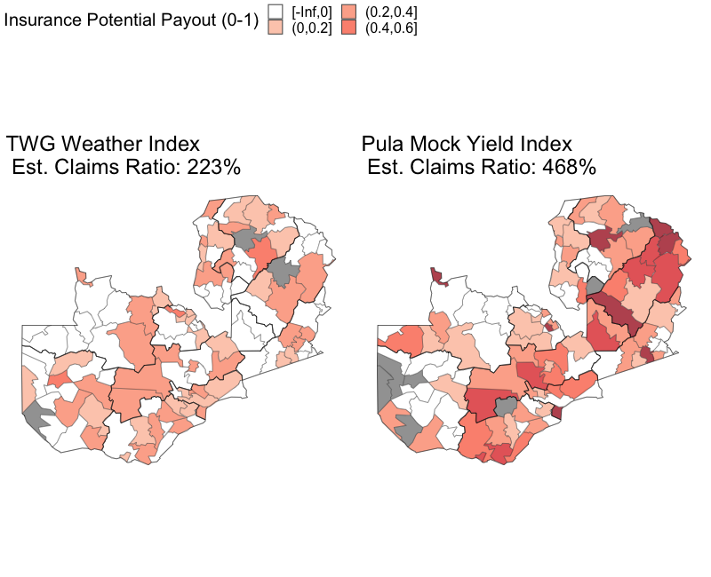

### 2.2 Evaluation of Report-Based Audit Rule

#### **A blended index would have required only ~1/5th as many yield assessments as AY alone in 2021/22.**

#### **This index would have identified the majority of districts which experienced low yields.**

The above results, along with the results of Section 1, suggests that WII can capture some but not all of the information that AY can (and that the MoA’s own yield assessments could perform the functions of AY well). At the same time, a full national AY assessment is expensive and time-consuming - the results may not be known until 4-5 months after harvest, at which point insurance payouts will have arrived too late to cover many of farmers’ most crucial expenses.

Thus, we want to think about how yield audits could be introduced in a strategic, targeted way. Since we do not know in advance whether a year will be bad for farmers, we need a transparent, timely standard for when to trigger yield audits. We propose using rapid survey feedback from MoA camp extension officers.

This data has already been gathered once – during the 2021/22 season, from over 300 extension officers. Officers we asked to assess whether or not their district experienced crop loss due to excess rainfall or drought, and to qualitatively assess the historical severity of that loss.

Using this, we can explore a simple audit rule, in which yield assessments would be triggered in districts where the WII product did NOT present a payout AND where officers said conditions were “much worse” than the historical average. Since we also have comprehensive yield data for 2021/22, we can ask: would targeting yield audits based on officer feedback have correctly identified the areas of poor yield? Also, would these audits have significantly reduced basis risk compared to WII alone?

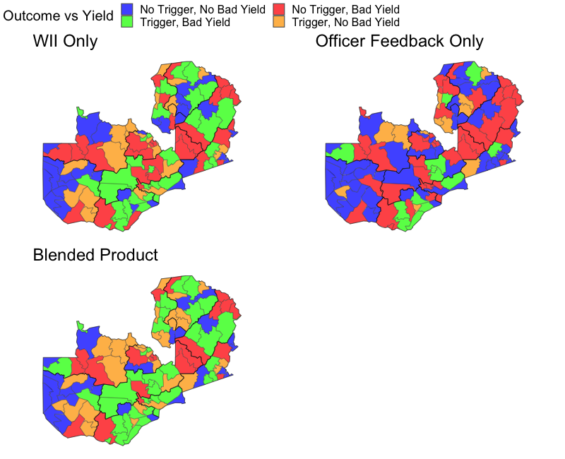

We can see that the results are mixed. 25 districts (approximately 1/5th of districts) would have triggered an audit; among those, about half were in a district that would have presented low enough yields to receive a payout, while half were not. As a specific example, incorporating audits would have correctly identified several areas around Central and Lusaka provinces as in need of payouts which they did not receive from WII alone. These were areas which experienced flooding which was not covered by the weather index.

#### **However, there would have been many false positives.**

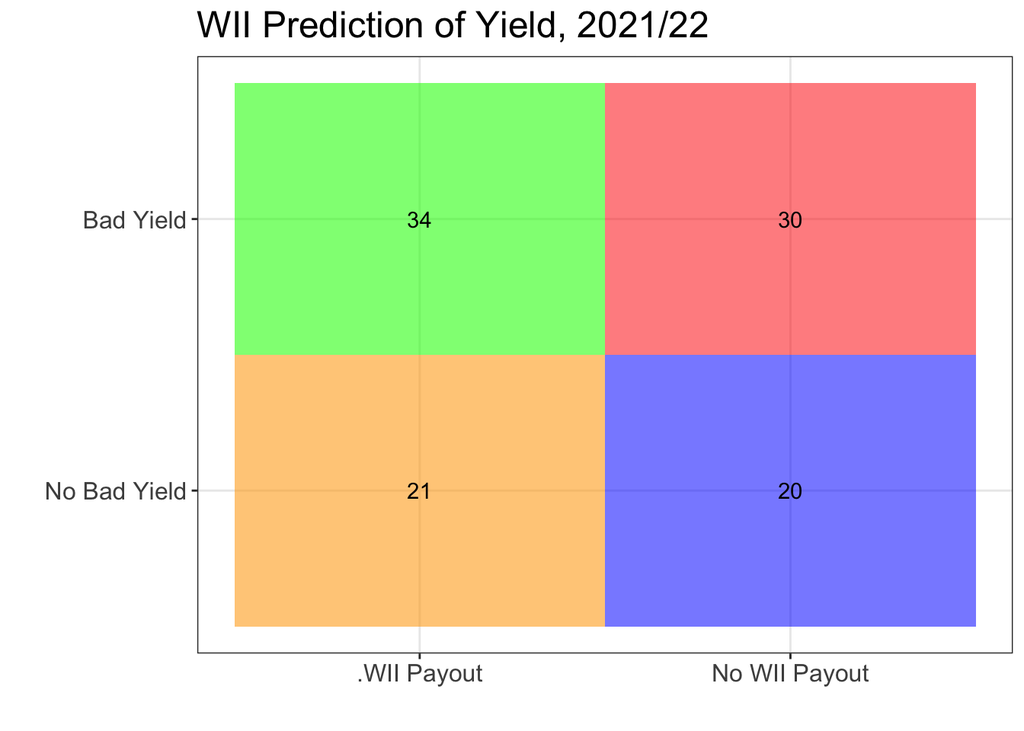

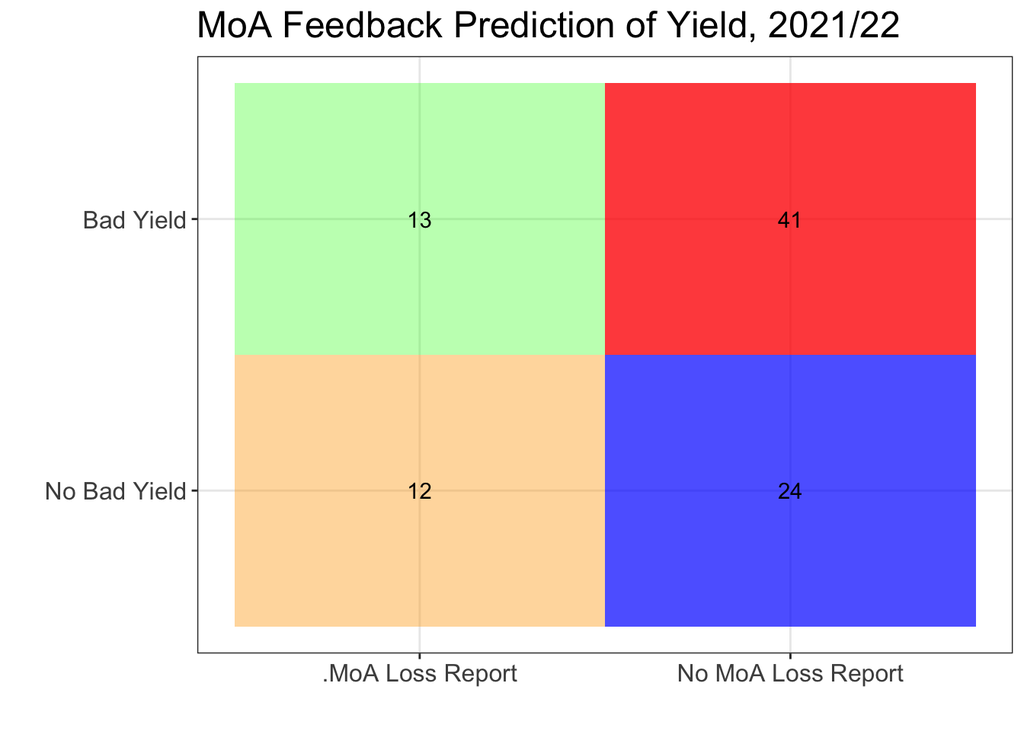

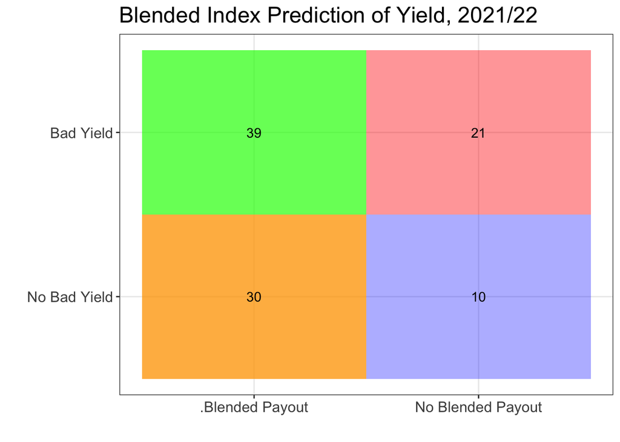

In short, the 2021/22 season offers promising early evidence on the viability of targeted yield audits, but more research is needed on how to best operationalize this audit procedure. The MoA is collecting more detailed feedback data for the 2022/23 season, so there will be more analysis to share soon.

It is important to note that area yield assessments can vary significantly from one another, even within a locality. Appendix 3.3 visualizes this variability. In our 2021/22 area yield data from Pula, it is apparent that the variability within districts frequently exceeds the variability between districts. This may be due to imprecision in measurement, actual differences between neighboring farmers’ outcomes, or some combination of the two. In any case, this variability informs the scale at which our results are meaningful.

## 3. Appendix

### 3.1 WII Production Claims Comparison

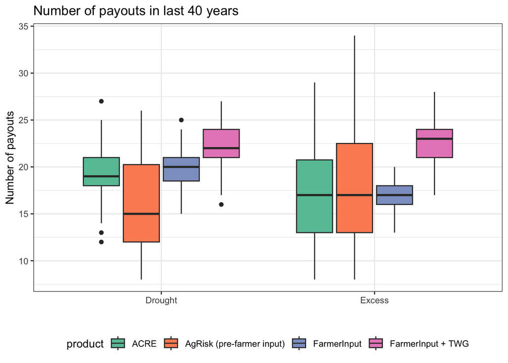

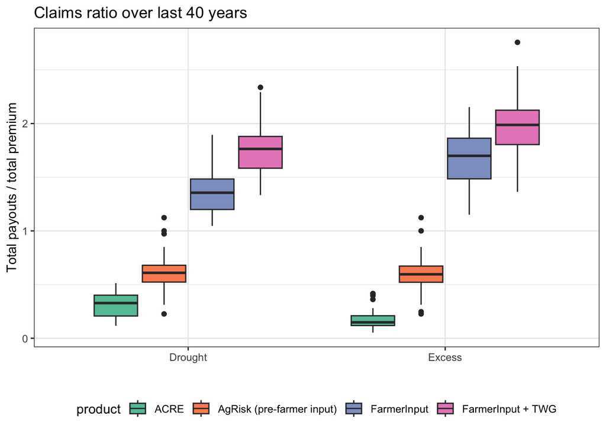

The products differ in terms of their historical average claims ratios. To account for this, the financial analysis in this report normalizes all figures by the total historical claims for that product.

### 3.2 Weather Insurance vs Area Yield Matching

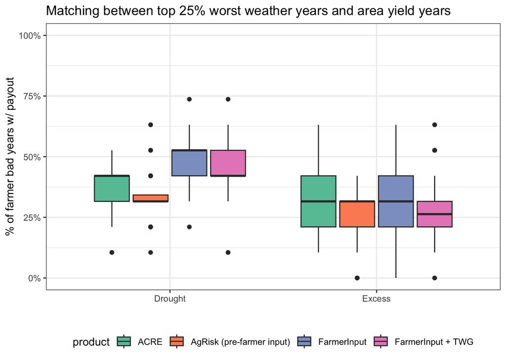

### 3.3 Variability in Pula Crop Cuts

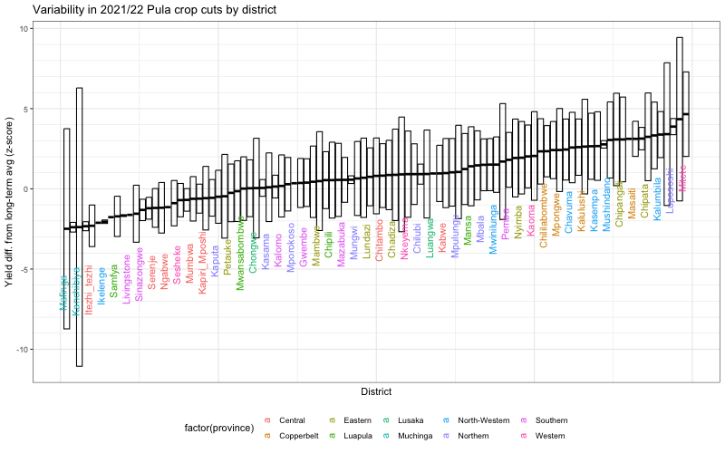